# Homer, Iliad

5 September 2017

## The 8th Century BC

- Colonization
  - Corcyra, settled by Corinthians, *c*.734 BC
  - Syracuse, settled by Corinthians, *c*.734 BC
  - Cumae, settled by Chalcidians, before 725 BC
- Panhellenic Games
  - First Olympic games 776 BC, led to Olympiad dating system. 2017/8 = 1st year of the 699th Olympiad.
  - Pythian Games at Delphi; music and athletic competitions; every 8 years at first, after 585 BC held 3rd year of each Olympiad
  - Nemean and Isthmian games held in 2nd and 4th years of each Olympiad from the c6 onward

## Writing

- Linear B (extinct *c*.1100 BC) –> Cypriot Syllabary (extince *c*.300 BC)
  - Syllabic (consonant & vowel)
- Phoenecian
  - Abjad (consonants only, no vowels)
  - Derived from Egyptian heiroglyphs
  - Evolved into Greek, Latin, Hebrew, Syriac, Arabic, and other scripts

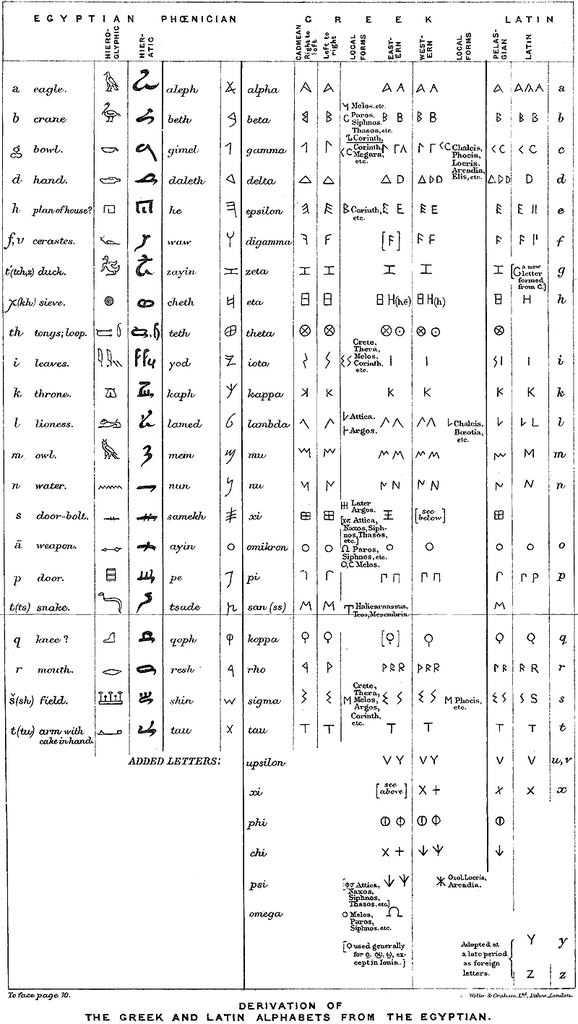

[figure not shown]

Neck of the "Nessos Amphora," Athens, 625-600 BC, National Archaeological Museum

[figure not shown]

The "Cup of Nestor" From Pithekoussai, *c*. 750-700 BC. Cf *Iliad*, 11.632-637.

## Homer

[figure not shown]

'Homer Caetani', Roman copy (C2 AD?) of Hellenistic statue

## A real person?

- Poems date to second half C8: *Iliad* *c*.750, *Odyssey* *c*. 725 BC.
- Ancients attributed both to the same poet, Homer
- Chios and Smyrna (Asia Minor) have best claim to be his birthplace
- Debate about unity of poems C18 - early C20, put to rest by better understanding of oral poetry composition
- Poems have "fossilized" memory of Mycenean past (ended *c*.1200 BC), supported by archaeology; reflect Dark Age society

## *Iliad* 18 & *Ekphrasis*

- *Ekphrasis*: "Extended and detailed lieterary description of any object, real or imaginary."
  - Valuable for art history
  - Literary genre, sometimes used as rhetorical exercise
  - e.g. Lucian, *Eikones* (C2 AD); Philostratus of Lemnos, *Eikones* (early C3 AD); Callistratus, *Ekphraseis* (C3 or 4 AD)

[figure not shown]

## Gods and War: *Iliad* 18.516-9.

… And Ares led them, and Pallas Athene. // These were gold, both, and golden raiment upon them, and they were // beautiful and huge in their armour, being divinities, // and conspicuous from afar, but the people around them were smaller.

Tr. Lattimore (1951)

## Agriculture and sacrifice: *Iliad* 18.558-60.

And apart and under a tree the heralds made a feast ready // and trimmed a great ox they had slaughtered. Meanwhile the women // scattered, for the wormken to eat, abundant white barley.

Tr. Lattimore (1951)

## Performance: *Iliad* 18.569-72.

And in their midst a youth with a singing lyre played charmingly // upon it for them, and sang the beautiful song for Linos // in a light voice, and they followed him, and with singing and whistling // and light dance-steps of their feet kept time to the music.

Tr. Lattimore (1951)

## Vivid details: *Iliad* 18.535-8; 18.582-4.

And Hate was there with Confusion among the, and Death the destructive; // she was holding a live man with a new wound, and another // one unhurt, and dragged a dead man by the feet through the carnage. // The clothing upon her shoulders showed strong red with the men's blood.

But the two lions, breaking open th hide of the great ox, // gulped the black blood and the inward guts, as meanwhile herdsmen // were in the act of setting and urging the quick dogs on them.

Tr. Lattimore (1951)

## Mythological References: *Iliad* 18.590-2.

And the renowned smith of the strong arms made elaborate on it // a dancing floor, like that which once in the wide spaces of Knossos // Daidalos built for Ariadne of the lovely tresses.

Tr. Lattimore (1951)

## Geography: *Iliad* 18.606-7.

He made on it the great strength of the Ocean River // which ran around the utmost rim of the shield's strong structure.

Tr. Lattimore (1951)